# Data Science i AI w bankowości - lista 2 część 2 - Dobór Modelu XGBoost

Zuzanna Nogala

```python
import numpy as np
import pandas as pd
import seaborn as sns
import matplotlib.pyplot as plt
import matplotlib.ticker as mtick

import shap

import json

import xgboost as xgb
from sklearn.preprocessing import LabelEncoder
from sklearn.model_selection import train_test_split, cross_val_score, StratifiedKFold
from sklearn.metrics import roc_auc_score, roc_curve, make_scorer
from sklearn.inspection import permutation_importance

from skopt.space import Integer, Real
from skopt import BayesSearchCV
```

```python
sns.set_theme(style="whitegrid", context="notebook", palette="viridis", font_scale=0.9)
sns.set_style({'grid.linestyle': '--'})
plt.rcParams['figure.figsize'] = (10, 6)
```

# Funkcje

```python
def gini(true_val, predicted_val):
    return 2 * roc_auc_score(true_val, predicted_val) - 1

def model_summary(model, model_name, model_description,
                  train_set, test_set, valid_set,
                  y_train, y_test, y_valid):

    results_df = pd.DataFrame({'Model': [model_name],
                              'Model_Description': [model_description],
                              'Number_of_Vars': [model.n_features_in_],
                              'Gini_Train': [gini(y_train, model.predict_proba(train_set)[:, 1])],
                              'Gini_Test': [gini(y_test, model.predict_proba(test_set)[:, 1])],
                              'Gini_Valid': [gini(y_valid, model.predict_proba(valid_set)[:, 1])]})

    return results_df

def fi_plot(columns_name, metric_df, metric_name, ax=None, title='Feature Importance'):
    metric_df_to_plot = metric_df.loc[metric_df.variable.isin(columns_name)]

    sns.barplot(data = metric_df_to_plot,
            x = f'{metric_name}_norm',
            y = 'variable',
            ax=ax)
    plt.plot()
    ax.set_title(title)
    ax.set_xlabel(f'{metric_name} metric')

def get_feats_plots(model, train_set, y_train, n_repeats=10, random_state=0):
    metric_name = 'gain'
    metric_dict = model.get_booster().get_score(importance_type = metric_name)

    metric_df = pd.DataFrame({'variable': metric_dict.keys(), metric_name: metric_dict.values()})
    metric_df[f'{metric_name}_norm'] = metric_df[metric_name] / metric_df[metric_name].sum()
    metric_df = metric_df.sort_values(f'{metric_name}_norm', ascending=False)

    pi_results = permutation_importance(model, train_set, y_train, n_repeats=n_repeats, random_state=random_state)

    pi_df = pd.DataFrame({'variable': train_set.columns,
                      'importance_norm': pi_results['importances_mean']}).sort_values('importance_norm', ascending=False)

    fig, axes = plt.subplots(1, 2, figsize=(18, 8))
    #axes = axes.flatten()

    fi_plot(columns_name = train_set.columns, metric_df = metric_df, metric_name = metric_name, title='Feature Importance - GAIN metric', ax=axes[0])
    fi_plot(columns_name = train_set.columns, metric_df = pi_df, metric_name = "importance", title='Feature Importance - permutation', ax=axes[1])
    plt.show()

def draw_gini_vs_variable(model, train_set, y_train, test_set, y_test, title_name, params=None, n_repeats=10, random_state=42):
    pi_results = permutation_importance(model, train_set, y_train, n_repeats=n_repeats, random_state=random_state)

    pi_df = pd.DataFrame({'variable': train_set.columns,
                        'importance': pi_results['importances_mean']}
                        ).sort_values('importance',
                                      ascending=False).reset_index(drop=True)

    results_df = pi_df.copy()
    results_df['gini_train'] = 0.0
    results_df['gini_test'] = 0.0

    for i in range(pi_df.shape[0]):
        vars = pi_df.iloc[0:(i + 1), 0]
        subset_train_set = train_set.loc[:, train_set.columns.isin(vars)]
        subset_test_set = test_set.loc[:, test_set.columns.isin(vars)]

        if params is None:
            model = xgb.XGBClassifier(**params)
        else:
            model = xgb.XGBClassifier(**params)

        model.fit(subset_train_set, y_train)
        train_preds = model.predict_proba(subset_train_set)[:, 1]
        test_preds = model.predict_proba(subset_test_set)[:, 1]

        results_df.loc[i, 'gini_train'] = gini(y_train, train_preds)
        results_df.loc[i, 'gini_test'] = gini(y_test, test_preds)


    plt.plot(results_df.gini_train, label = 'Gini w zbiorze treningowym', marker='o')
    plt.plot(results_df.gini_test, label = 'Gini w zbiorze testowym', marker='o')
    plt.legend()
    plt.xlabel('Wazność zmiennej')
    plt.ylabel('Wartość Giniego')
    plt.title(title_name)
    plt.show()

    return results_df

def roc_curve_plot(y_true, y_pred, dataset_type = 'TRAIN'):
    fpr, tpr, _ = roc_curve(y_true, y_pred)

    auc = roc_auc_score(y_true, y_pred)
    sns.lineplot(x = fpr, y = tpr, label = f"{dataset_type} - AUC = {np.round(auc, 3)}")
    # sns.lineplot(x = np.arange(0,1.1,0.1), y = np.arange(0,1.1,0.1), color = 'black')

    ax = plt.gca()
    ax.xaxis.set_major_formatter(mtick.PercentFormatter(xmax=1, decimals=0))
    ax.yaxis.set_major_formatter(mtick.PercentFormatter(xmax=1, decimals=0))

    plt.xlabel("TPR")
    plt.ylabel("FPR")
```

# Wstęp

Celem raportu jest budowa i optymalizacja modelu klasyfikacyjnego opartego na algorytmie XGBoost. Model posłuży do prognozowania skłonności klientów do założenia lokaty terminowej w portugalskiej instytucji bankowej na podstawie ich profilu demograficznego, statusu finansowego oraz historii dotychczasowych kontaktów marketingowych. Dane obejmują interakcje realizowane od maja 2008 roku do listopada 2010 roku.

Szczegółowa analiza jakościowa oraz eksploracyjna tego zbioru danych została szczegółowo przedstawiona w części 1 raportu, tj. "Data Science i AI w bankowości - lista 2 część 1 - Jakość Danych".

Raport obejmuje następujące kroki badawcze:

- analizę i ocenę podstawowych wariantów modelu XGBoost: budowę modeli bazowych na pełnym zestawie zmiennych objaśniających oraz ocenę ich zdolności dyskryminacyjnej przy użyciu współczynnika Giniego ($Gini = 2 \cdot AUC - 1$).
- selekcję zmiennych i optymalizację struktury: wybór najbardziej efektywnego zestawu predyktorów w celu eliminacji współliniowości zidentyfikowanej w poprzedniej części analizy.
- wybór modelu wiodącego (Champion): wyłonienie najlepszej konfiguracji algorytmu na podstawie metryk jakości na wydzielonych zbiorach.
- szczegółową analitykę modelu Champion: interpretację działania wybranego modelu w oparciu o ranking ważności cech (Feature Importance) oraz ocenę stabilności predykcji i dopasowania do danych.

```python
# Dane bazowe
df = pd.read_csv("bank-full.csv", sep = ';')
df['client_id'] = df.index
df['y'] = df['y'].map({'no': 0, 'yes': 1})

# Dane, gdzie zmienne kategoryczne zostały przekształcone na numerycznie (Label Encoding)
df_labeled = df.copy()

encoder = LabelEncoder()
for col in df_labeled.select_dtypes(include=['object', 'string']).columns:
    df_labeled[col] = encoder.fit_transform(df_labeled[col])

X_train, X_test, y_train, y_test = train_test_split(df_labeled.drop(columns = ['y', 'client_id']),
                                                    df_labeled.y, test_size=0.4, random_state=20)
X_test, X_valid, y_test, y_valid = train_test_split(X_test,
                                                    y_test, test_size=0.5, random_state=20)

# Dane, gdzie zmienne kategoryczne zostały przekształcone na zmienne typu Dummy (One-Hot/Dummy Encoding)
df_to_dummys = pd.read_csv("bank-full.csv", sep = ';')
df_to_dummys['y'] = df_to_dummys['y'].map({'no': 0, 'yes': 1})

df_dummy = pd.get_dummies(df_to_dummys[[i for i in df_to_dummys.columns if i!= 'y']])

df_dummy = df_dummy.drop(columns = ['job_admin.', 'marital_divorced', 'education_primary', 'default_no',
                         'housing_no', 'loan_no', 'contact_cellular', 'month_apr', 'poutcome_failure'])

X_train_d = df_dummy.iloc[X_train.index, :].copy()
X_test_d = df_dummy.iloc[X_test.index, :].copy()
X_valid_d = df_dummy.iloc[X_valid.index, :].copy()
```

# 1. Analiza podstawowych wariantów modeli XGBoost

W tej sekcji przeprowadzona zostanie analiza i ocena efektywności bazowych konfiguracji klasyfikatora XGBoost. Głównym celem tego etapu jest wyznaczenie punktu odniesienia (baseline) dla dalszych etapów optymalizacji hiperparametrów oraz zweryfikowanie, jak model XGBoost reaguje na odmienne sposoby reprezentacji danych. Zweryfikujemy, czy algorytm osiągnie wyższą zdolność dyskryminacyjną na zmiennych kategorycznych zakodowanych numerycznie (Label Encoding), czy też optymalniejszym wyborem okaże się przekształcenie ich w binarne zmienne fikcyjne (One-Hot / Dummy Encoding).

## 1.1 Modele z domyślnymi parametrami

```python
model1 = xgb.XGBClassifier()
model1.fit(X_train, y_train)
```

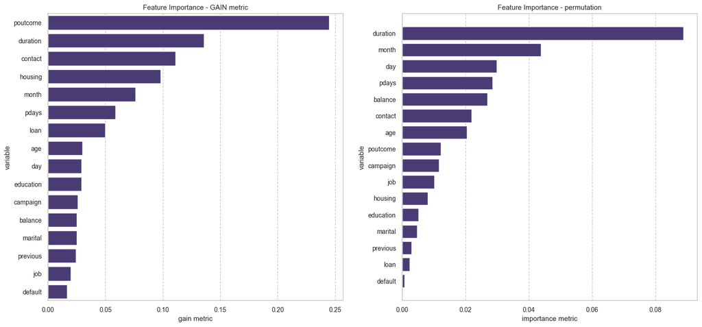

```python
get_feats_plots(model1, X_train, y_train)
```

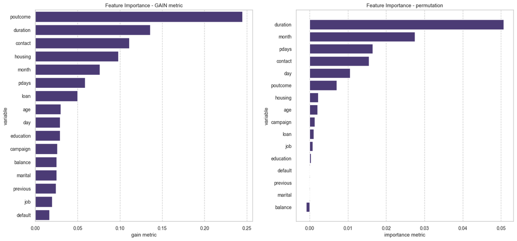

```python
get_feats_plots(model1, X_test, y_test)
```

```python
model1_results = model_summary(model1, 'Model 1', 'Model z domyślnymi parametrami i z zastosowaniem Label Encoding',
                                X_train, X_test, X_valid,
                                y_train, y_test, y_valid)

model1_results.style.format('{:.2%}', subset = ['Gini_Train', 'Gini_Test', 'Gini_Valid'])
```

|  | Model | Model_Description | Number_of_Vars | Gini_Train | Gini_Test | Gini_Valid |
| --- | --- | --- | --- | --- | --- | --- |
| 0 | Model 1 | Model z domyślnymi parametrami i z zastosowaniem Label Encoding | 16 | 97.05% | 87.49% | 86.22% |

Model oparty na pełnym zestawie zmiennych kategorycznych zakodowanych numerycznie przy domyślnych ustawieniach hiperparametrów, wykazuje wyraźne symptomy przeuczenia (overfittingu). Świadczy o tym wysoka wartość współczynnika Gini na zbiorze treningowym przy jednoczesnych mniejszych wynikach tej metryki na zbiorach testowym i walidacyjnym.

Zjawisko to potwierdza analiza ważności cech. Rankingi predyktorów wyznaczone dla zbioru treningowego na podstawie zysku (Gain) oraz ważności permutacyjnej (Permutation Importance) wykazują istotne rozbieżności z metrykami wyznaczonymi na zbiorach testowych. Co kluczowe, ewaluacja ważności permutacyjnej bezpośrednio na danych testowych ujawniła, że część zmiennych generuje szum – ich obecność w modelu wręcz obniża jego globalną moc dyskryminacyjną (np. zmienna balance ma ujemną ważność permutacyjną).

W kolejnym kroku analogicznej ocenie poddano model oparty na domyślnych parametrach, lecz wytrenowany na przestrzeni cech przekształconych do postaci Dummy.

```python
model2 = xgb.XGBClassifier()
model2.fit(X_train_d, y_train)
```

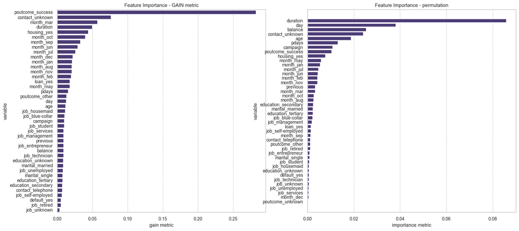

```python
get_feats_plots(model2, X_train_d, y_train)
```

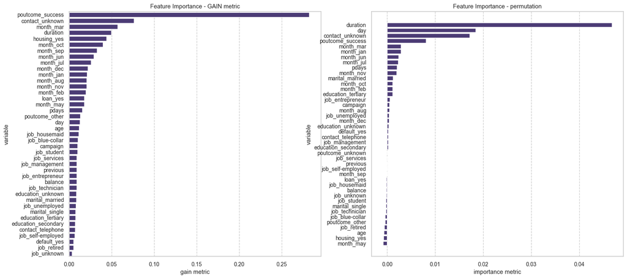

```python
get_feats_plots(model2, X_test_d, y_test)
```

```python
model2_results =  model_summary(model2, 'Model 2', 'Model z domyślnymi parametrami z zastosowaniem Dummy Encoding',
                                X_train_d, X_test_d, X_valid_d,
                                y_train, y_test, y_valid)

models_results = pd.concat([model1_results, model2_results]).reset_index(drop = True)
models_results.style.format('{:.2%}', subset = ['Gini_Train', 'Gini_Test', 'Gini_Valid'])
```

|  | Model | Model_Description | Number_of_Vars | Gini_Train | Gini_Test | Gini_Valid |
| --- | --- | --- | --- | --- | --- | --- |
| 0 | Model 1 | Model z domyślnymi parametrami i z zastosowaniem Label Encoding | 16 | 97.05% | 87.49% | 86.22% |
| 1 | Model 2 | Model z domyślnymi parametrami z zastosowaniem Dummy Encoding | 42 | 96.68% | 87.64% | 85.63% |

Dodatkowo analiza ważności cech (zarówno oparta na zysku, jak i na permutacji) ujawniła analogiczne anomalie jak w modelu bazowym, potwierdzając obecność szumu.

W związku z tym, że sama manipulacja sposobem kodowania danych nie rozwiązała problemu nadmiernego dopasowania, w kolejnym kroku wdrożono optymalizację bayesowską. Celem tego zabiegu jest weryfikacja, czy ta optymalizacja pozwoli na redukcję overfittingu oraz poprawę stabilności predykcji.

## 1.2 Modele z parametrami wybranych poprzez optymalizację Bayesa

```python
model3 = xgb.XGBClassifier()

params_space = {
    'n_estimators': Integer(50, 200),
    'max_depth': Integer(3, 10),
    'min_child_weight': Integer(1, 200),
    'learning_rate': Real(0.01, 0.3, prior='log-uniform'),
    'subsample': Real(0.6, 1.0),
    'colsample_bytree': Real(0.6, 1.0),
    'gamma': Real(1e-4, 10, prior='log-uniform'),
    'reg_lambda': Real(1e-4, 10, prior='log-uniform'),
    'reg_alpha': Real(1e-4, 10, prior='log-uniform'),
}

grid_seach1 = BayesSearchCV(
    estimator=model3,
    search_spaces=params_space,
    scoring='neg_mean_squared_error',
    n_iter=50,
    cv=3,
    verbose=0,
    random_state=42
)

grid_seach1.fit(X_train, y_train)
```

```
BayesSearchCV(cv=3,
              estimator=XGBClassifier(base_score=None, booster=None,
                                      callbacks=None, colsample_bylevel=None,
                                      colsample_bynode=None,
                                      colsample_bytree=None, device=None,
                                      early_stopping_rounds=None,
                                      enable_categorical=False,
                                      eval_metric=None, feature_types=None,
                                      feature_weights=None, gamma=None,
                                      grow_policy=None, importance_type=None,
                                      interaction_constraints=No...
                             'min_child_weight': Integer(low=1, high=200, prior='uniform', transform='normalize'),
                             'n_estimators': Integer(low=50, high=200, prior='uniform', transform='normalize'),
                             'reg_alpha': Real(low=0.0001, high=10, prior='log-uniform', transform='normalize'),
                             'reg_lambda': Real(low=0.0001, high=10, prior='log-uniform', transform='normalize'),
                             'subsample': Real(low=0.6, high=1.0, prior='uniform', transform='normalize')})
```

```python
grid_seach1.best_params_
```

```
OrderedDict([('colsample_bytree', 1.0),
             ('gamma', 0.42210016413900475),
             ('learning_rate', 0.04078026871684014),
             ('max_depth', 6),
             ('min_child_weight', 1),
             ('n_estimators', 200),
             ('reg_alpha', 0.07037434451736549),
             ('reg_lambda', 0.20287221997398708),
             ('subsample', 0.7601836719302151)])
```

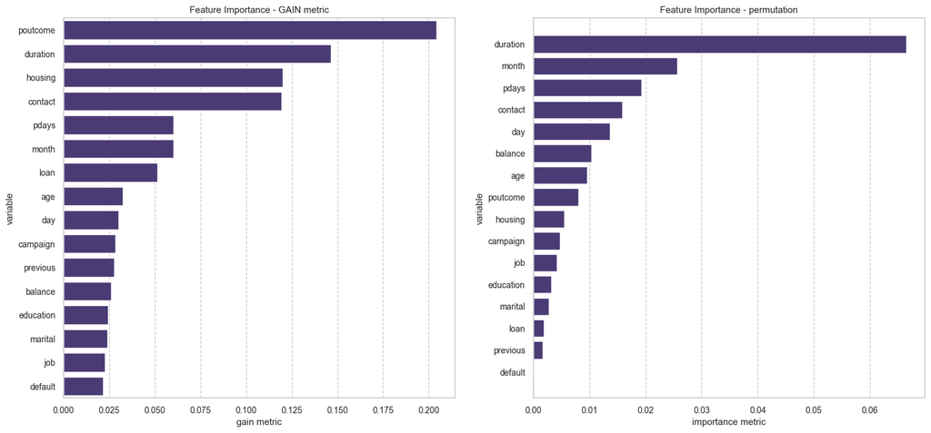

```python
get_feats_plots(grid_seach1.best_estimator_, X_train, y_train)
```

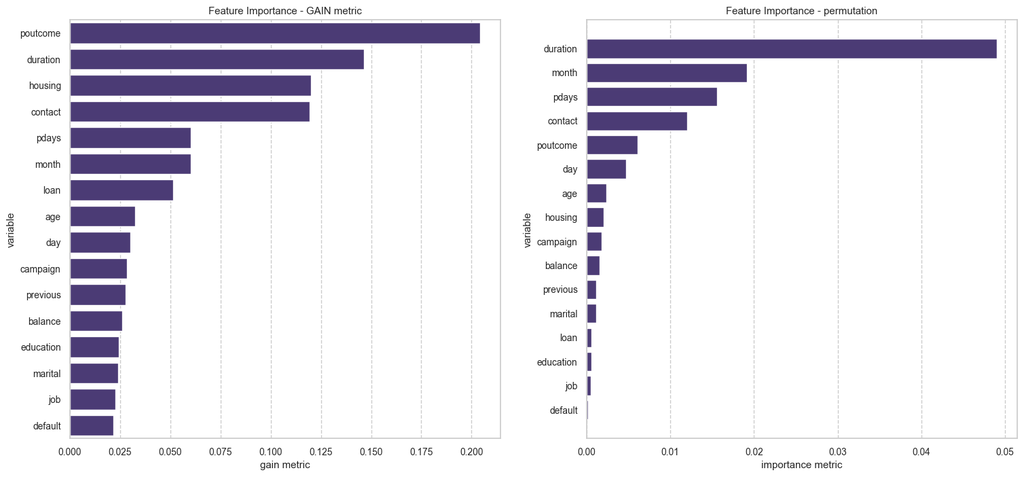

```python
get_feats_plots(grid_seach1.best_estimator_, X_test, y_test)
```

```python
model3_results = model_summary(grid_seach1.best_estimator_, 'Model 3', 'Model z parametrami wybranymi w optymalizacji Bayesa z zastosowaniem Label Encoding',
                                X_train, X_test, X_valid,
                                y_train, y_test, y_valid)

models_results = pd.concat([models_results, model3_results]).reset_index(drop = True)
models_results.style.format('{:.2%}', subset = ['Gini_Train', 'Gini_Test', 'Gini_Valid'])
```

|  | Model | Model_Description | Number_of_Vars | Gini_Train | Gini_Test | Gini_Valid |
| --- | --- | --- | --- | --- | --- | --- |
| 0 | Model 1 | Model z domyślnymi parametrami i z zastosowaniem Label Encoding | 16 | 97.05% | 87.49% | 86.22% |
| 1 | Model 2 | Model z domyślnymi parametrami z zastosowaniem Dummy Encoding | 42 | 96.68% | 87.64% | 85.63% |
| 2 | Model 3 | Model z parametrami wybranymi w optymalizacji Bayesa z zastosowaniem Label Encoding | 16 | 92.70% | 88.26% | 87.14% |

Zastosowanie optymalizacji bayesowskiej dla modelu opartego na zmiennych zakodowanych numerycznie (Label Encoding) przyniosło oczekiwaną poprawę wyników. W rezultacie otrzymaliśmy kontrolowany spadek współczynnika Gini na zbiorze treningowym przy jednoczesnym wzroście tej metryki na danych testowych i walidacyjnych. Zabieg ten skutecznie zredukował zjawisko przeuczenia.

Kluczowym dowodem na poprawę struktury modelu jest stabilizacja ważności cech. Ewaluacja ważności permutacyjnej na zbiorach testowym oraz walidacyjnym wykazała, że po optymalizacji żadna z uwzględnionych zmiennych nie generuje szumu i nie wpływa negatywnie na globalną moc dyskryminacyjną klasyfikatora.

Mając na uwadze sukces optymalizacji parametrycznej, następnie zweryfikujemy czy znalezione hiperparametry przeniosą się na alternatywną przestrzeń cech, w tym przypadku na zmienne typu Dummy.

```python
model4 = xgb.XGBClassifier(**grid_seach1.best_params_)
model4.fit(X_train_d, y_train)
```

```
XGBClassifier(base_score=None, booster=None, callbacks=None,
              colsample_bylevel=None, colsample_bynode=None,
              colsample_bytree=1.0, device=None, early_stopping_rounds=None,
              enable_categorical=False, eval_metric=None, feature_types=None,
              feature_weights=None, gamma=0.42210016413900475, grow_policy=None,
              importance_type=None, interaction_constraints=None,
              learning_rate=0.04078026871684014, max_bin=None,
              max_cat_threshold=None, max_cat_to_onehot=None,
              max_delta_step=None, max_depth=6, max_leaves=None,
              min_child_weight=1, missing=nan, monotone_constraints=None,
              multi_strategy=None, n_estimators=200, n_jobs=None,
              num_parallel_tree=None, ...)
```

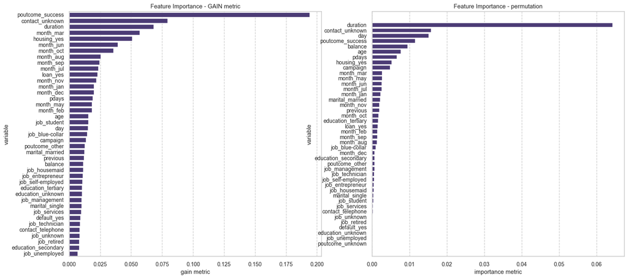

```python
get_feats_plots(model4, X_train_d, y_train)
```

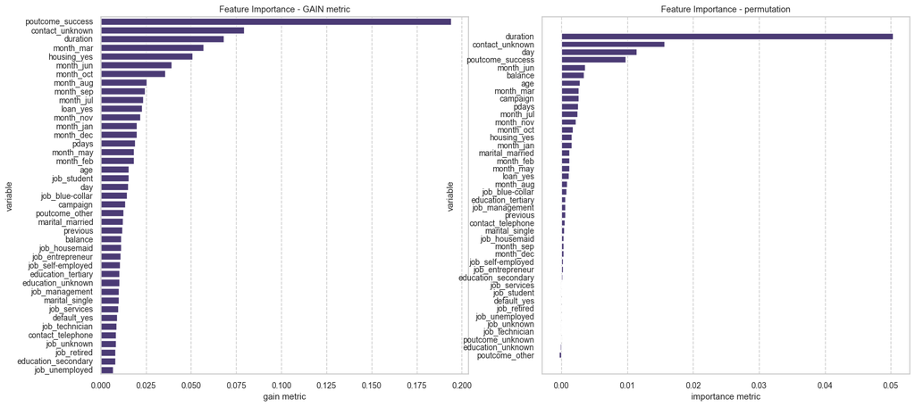

```python
get_feats_plots(model4, X_test_d, y_test)
```

```python
model4_results =  model_summary(model4, 'Model 4',
                                'Model z parametrami wybranymi w optymalizacji Bayesa dla Modelu 3 z zastosowaniem Dummy Encoding',
                                X_train_d, X_test_d, X_valid_d,
                                y_train, y_test, y_valid)

models_results = pd.concat([models_results, model4_results]).reset_index(drop = True)
models_results.style.format('{:.2%}', subset = ['Gini_Train', 'Gini_Test', 'Gini_Valid'])
```

|  | Model | Model_Description | Number_of_Vars | Gini_Train | Gini_Test | Gini_Valid |
| --- | --- | --- | --- | --- | --- | --- |
| 0 | Model 1 | Model z domyślnymi parametrami i z zastosowaniem Label Encoding | 16 | 97.05% | 87.49% | 86.22% |
| 1 | Model 2 | Model z domyślnymi parametrami z zastosowaniem Dummy Encoding | 42 | 96.68% | 87.64% | 85.63% |
| 2 | Model 3 | Model z parametrami wybranymi w optymalizacji Bayesa z zastosowaniem Label Encoding | 16 | 92.70% | 88.26% | 87.14% |
| 3 | Model 4 | Model z parametrami wybranymi w optymalizacji Bayesa dla Modelu 3 z zastosowaniem Dummy Encoding | 42 | 92.18% | 88.46% | 87.24% |

Zastosowanie hiperparametrów znalezionych w poprzednim kroku do przestrzeni zmiennych typu dummy przyniosła wyraźną poprawę w stosunku do wariantu domyślnego. Można zaobserwować redukcję nadmiernego dopasowania na zbiorze treningowym oraz wzrost współczynnika Gini na zbiorach niezależnych. Co więcej, wariant ten osiągnął nieznacznie wyższą moc dyskryminacyjną na danych testowych i walidacyjnych niż zoptymalizowany model oparty na kodowaniu numerycznym (Label Encoding).

Pomimo obiecujących wartości metryk globalnych, ważności cech wyznaczone metodami Gain oraz ważności permutacyjnej straciły swoją spójność pomiędzy zbiorem treningowym a testowym. Permutacja na danych testowych ponownie wykazała obecność szumu wokół niektórych zmiennych, co bezpośrednio obniża końcowy potencjał klasyfikatora.

Zaobsetwowana niespójność wynika z faktu, że przeniesienie hiperparametrów do znacznie szerszej macierzy zmiennych okazało się nieoptymalne – model budowany na innych zmiennych wymaga niezależnej optymalizacji. W związku z tym zastosujemy procedurę optymalizacji bezpośrednio na zbiorze ze zmiennymi typu Dummy.

```python
model5 = xgb.XGBClassifier()

grid_seach2 = BayesSearchCV(
    estimator=model5,
    search_spaces=params_space,
    scoring='neg_mean_squared_error',
    n_iter=50,
    cv=3,
    verbose=0,
    random_state=42
)

grid_seach2.fit(X_train_d, y_train)
```

```
BayesSearchCV(cv=3,
              estimator=XGBClassifier(base_score=None, booster=None,
                                      callbacks=None, colsample_bylevel=None,
                                      colsample_bynode=None,
                                      colsample_bytree=None, device=None,
                                      early_stopping_rounds=None,
                                      enable_categorical=False,
                                      eval_metric=None, feature_types=None,
                                      feature_weights=None, gamma=None,
                                      grow_policy=None, importance_type=None,
                                      interaction_constraints=No...
                             'min_child_weight': Integer(low=1, high=200, prior='uniform', transform='normalize'),
                             'n_estimators': Integer(low=50, high=200, prior='uniform', transform='normalize'),
                             'reg_alpha': Real(low=0.0001, high=10, prior='log-uniform', transform='normalize'),
                             'reg_lambda': Real(low=0.0001, high=10, prior='log-uniform', transform='normalize'),
                             'subsample': Real(low=0.6, high=1.0, prior='uniform', transform='normalize')})
```

```python
grid_seach2.best_params_
```

```
OrderedDict([('colsample_bytree', 0.8839152274490003),
             ('gamma', 0.004176822964985784),
             ('learning_rate', 0.051842218263107656),
             ('max_depth', 5),
             ('min_child_weight', 8),
             ('n_estimators', 200),
             ('reg_alpha', 0.9068357013924325),
             ('reg_lambda', 0.41698632372864874),
             ('subsample', 0.9921170354499472)])
```

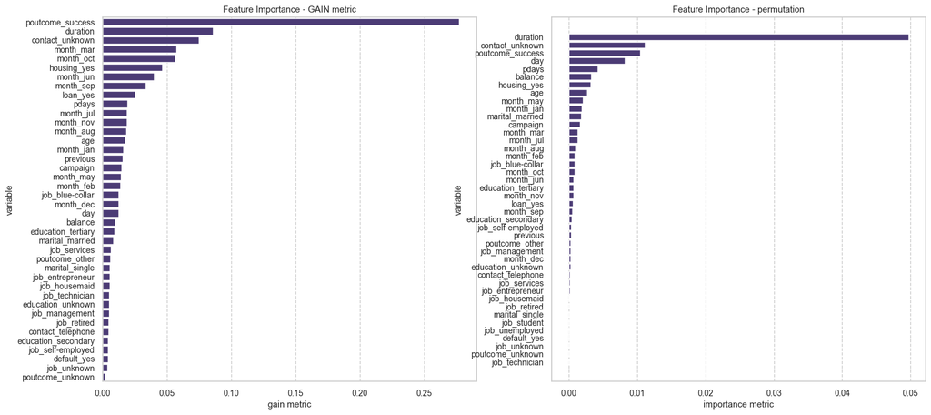

```python
get_feats_plots(grid_seach2.best_estimator_, X_train_d, y_train)
```

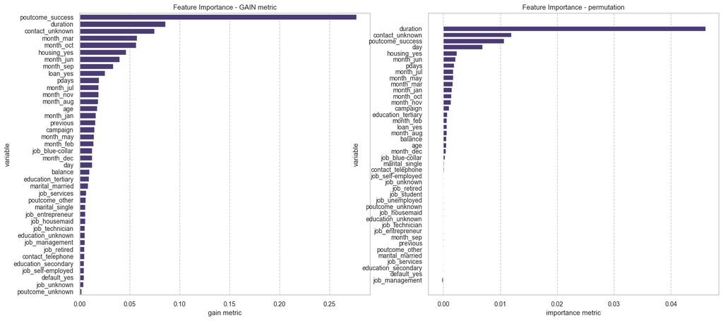

```python
get_feats_plots(grid_seach2.best_estimator_, X_test_d, y_test)
```

## 1.3 Finalne wyniki

```python
model5_results =  model_summary(grid_seach2.best_estimator_, 'Model 5',
                                'Model z parametrami wybranymi w optymalizacji Bayesa z zastosowaniem Dummy Encoding',
                                X_train_d, X_test_d, X_valid_d,
                                y_train, y_test, y_valid)

models_results = pd.concat([models_results, model5_results]).reset_index(drop = True)
models_results.style.format('{:.2%}', subset = ['Gini_Train', 'Gini_Test', 'Gini_Valid'])
```

|  | Model | Model_Description | Number_of_Vars | Gini_Train | Gini_Test | Gini_Valid |
| --- | --- | --- | --- | --- | --- | --- |
| 0 | Model 1 | Model z domyślnymi parametrami i z zastosowaniem Label Encoding | 16 | 97.05% | 87.49% | 86.22% |
| 1 | Model 2 | Model z domyślnymi parametrami z zastosowaniem Dummy Encoding | 42 | 96.68% | 87.64% | 85.63% |
| 2 | Model 3 | Model z parametrami wybranymi w optymalizacji Bayesa z zastosowaniem Label Encoding | 16 | 92.70% | 88.26% | 87.14% |
| 3 | Model 4 | Model z parametrami wybranymi w optymalizacji Bayesa dla Modelu 3 z zastosowaniem Dummy Encoding | 42 | 92.18% | 88.46% | 87.24% |
| 4 | Model 5 | Model z parametrami wybranymi w optymalizacji Bayesa z zastosowaniem Dummy Encoding | 42 | 89.05% | 88.20% | 86.85% |

Natomiast w dalszym ciągu jest widoczny brak pełnej spójności w rankingach ważności cech pomiędzy zbiorem treningowym a testowym, sygnalizując obecność szumu. Warto podkreślić, że przy tak znacznym rozszerzeniu przestrzeni cech (wzrost do 42 zmiennych po zakodowaniu One-Hot) zjawisko to jest naturalną konsekwencją tzw. klątwy wymiarowości.

Mając na uwadze niejednoznaczne zachowanie metryk na pojedynczym podziale danych, kazdy wariant modelu XGBoost oddamy ostatecznej weryfikacji za pomocą procedury 10-krotnej walidacji krzyżowej (10-Fold Cross-Validation). Decyzja o wyborze 10 foldów jest podyktowana dużą liczebnością próby treningowej (27 126 obserwacji). Taki podział pozwoli nam na uzyskanie licznych (ok. 2700 rekordów) i reprezentatywnych podzbiorów walidacyjnych w każdej iteracji, co maksymalnie uwiarygadnia końcowe wnioski. Pozwoli to nam jednoznacznie rozstrzygnąć, czy zaobserwowane różnice oraz fluktuacje jakości predykcyjnej mają charakter statystycznie istotny, czy są jedynie dziełem przypadku wynikającym z losowego podziału prób.

```python
# best_parameters_M3 = grid_seach1.best_params_
# best_parameters_M5 = grid_seach2.best_params_

# with open('best_params_M3_labeled.json', 'w') as f:
#     json.dump(best_parameters_M3, f, indent=4)

# with open('best_params_M5_dummy.json', 'w') as f:
#     json.dump(best_parameters_M5, f, indent=4)

with open('best_params_M3_labeled.json', 'r') as f:
    loaded_params_M3 = json.load(f)

with open('best_params_M5_dummy.json', 'r') as f:
    loaded_params_M5 = json.load(f)

model3_labeled = xgb.XGBClassifier(**loaded_params_M3)
model5_dummy = xgb.XGBClassifier(**loaded_params_M5)

model3_labeled.fit(X_train, y_train)
model5_dummy.fit(X_train_d, y_train)
```

```
XGBClassifier(base_score=None, booster=None, callbacks=None,
              colsample_bylevel=None, colsample_bynode=None,
              colsample_bytree=0.8839152274490003, device=None,
              early_stopping_rounds=None, enable_categorical=False,
              eval_metric=None, feature_types=None, feature_weights=None,
              gamma=0.004176822964985784, grow_policy=None,
              importance_type=None, interaction_constraints=None,
              learning_rate=0.051842218263107656, max_bin=None,
              max_cat_threshold=None, max_cat_to_onehot=None,
              max_delta_step=None, max_depth=5, max_leaves=None,
              min_child_weight=8, missing=nan, monotone_constraints=None,
              multi_strategy=None, n_estimators=200, n_jobs=None,
              num_parallel_tree=None, ...)
```

```python
gini_scorer = make_scorer(gini, response_method="predict_proba")

# równomierne rozłożenie y=1 po foldach
cv_strategy = StratifiedKFold(n_splits=10, shuffle=True, random_state=20)

model_1_xgb = xgb.XGBClassifier(**model1.get_params())
model_2_xgb = xgb.XGBClassifier(**model2.get_params())
model_3_xgb = xgb.XGBClassifier(**loaded_params_M3)
model_4_xgb = xgb.XGBClassifier(**loaded_params_M3)
model_5_xgb = xgb.XGBClassifier(**loaded_params_M5)

scores_m1 = cross_val_score(
    estimator=model_1_xgb,
    X=X_train,
    y=y_train,
    cv=cv_strategy,
    scoring=gini_scorer,
    n_jobs=2
)

scores_m2 = cross_val_score(
    estimator=model_2_xgb,
    X=X_train_d,
    y=y_train,
    cv=cv_strategy,
    scoring=gini_scorer,
    n_jobs=2
)

scores_m3 = cross_val_score(
    estimator=model_3_xgb,
    X=X_train,
    y=y_train,
    cv=cv_strategy,
    scoring=gini_scorer,
    n_jobs=2
)

scores_m4 = cross_val_score(
    estimator=model_4_xgb,
    X=X_train_d,
    y=y_train,
    cv=cv_strategy,
    scoring=gini_scorer,
    n_jobs=2
)

scores_m5= cross_val_score(
    estimator=model_5_xgb,
    X=X_train_d,
    y=y_train,
    cv=cv_strategy,
    scoring=gini_scorer,
    n_jobs=2
)

print("Współczynnik Gini z 10-krotnej walidacji krzyżowej:")
print(f"Model 1 (Label Encoding Bez Optymalizacji): Średni Gini = {np.mean(scores_m1):.2%} (+/- odchylenie std: {np.std(scores_m1):.2%})")
print(f"Model 2 (Dummy Encoding Bez Optymalizacji): Średni Gini = {np.mean(scores_m2):.2%} (+/- odchylenie std: {np.std(scores_m2):.2%})")
print(f"Model 3 (Label Encoding Z Optymalizacją): Średni Gini = {np.mean(scores_m3):.2%} (+/- odchylenie std: {np.std(scores_m3):.2%})")
print(f"Model 4 (Dummy Encoding Z Optymalizacją Z Modelu 3): Średni Gini = {np.mean(scores_m4):.2%} (+/- odchylenie std: {np.std(scores_m4):.2%})")
print(f"Model 5 (Dummy Encoding Z Optymalizacją ): Średni Gini = {np.mean(scores_m5):.2%} (+/- odchylenie std: {np.std(scores_m5):.2%})")
```

```
Współczynnik Gini z 10-krotnej walidacji krzyżowej:
Model 1 (Label Encoding Bez Optymalizacji): Średni Gini = 84.46% (+/- odchylenie std: 0.90%)
Model 2 (Dummy Encoding Bez Optymalizacji): Średni Gini = 84.48% (+/- odchylenie std: 0.79%)
Model 3 (Label Encoding Z Optymalizacją): Średni Gini = 85.83% (+/- odchylenie std: 0.94%)
Model 4 (Dummy Encoding Z Optymalizacją Z Modelu 3): Średni Gini = 85.93% (+/- odchylenie std: 0.75%)
Model 5 (Dummy Encoding Z Optymalizacją ): Średni Gini = 85.75% (+/- odchylenie std: 0.81%)
```

Zbiorcze zestawienie wyników 10-krotnej walidacji krzyżowej dla modeli pełnowymiarowych jednoznacznie wskazuje, że kluczowym czynnikiem podnoszącym jakość klasyfikacji była optymalizacja hiperparametrów za pomocą BayesSearchCV, generując stabilny przyrost średniego współczynnika Gini o około 1.4 p.p. w stosunku do modeli bazowych.

Najwyższą wartością współczynnika Gini na pełnej przestrzeni cech wykazał się wariant hybrydowy (Model 4), osiągając wynik na poziomie 85,93%. Ponieważ różnica efektywności między zoptymalizowanymi modelami opartymi na kodowaniu rzadkim (Model 4 i Model 5) okazała się statystycznie nieistotna i wyniosła zaledwie 0,18 p.p., do dalszego etapu redukcji wymiarowości skierowano Model 5, ponieważ algorytm optymalizacji Bayesowskiej poszukiwał dedykowanej konfiguracji hiperparametrów bezpośrednio na przestrzeni zmiennych fikcyjnych (Dummy Encoding), co zapewnia spójność strukturalną modelu z przetwarzanym zbiorem zmiennych danych.

Oprócz Modelu 5 przeanalizujemy Model 3, by zweryfikować która przestrzeń cech pozwoli na uzyskanie najwyższej i najbardziej stabilnej jakości predykcji.

Podsumowując etap testów wariantów bazowych: dwie najbardziej obiecujące architektury to zoptymalizowany model oparty na kodowaniu numerycznym (Model 3) oraz zoptymalizowany model oparty na zmiennych dummy (Model 5). W celu wyłonienia ostatecznego modelu champion, w kolejnym rozdziale spróbujemy zredukować wymiarowość w obu tych wariantach.

# 2. Wyłonienie modelu Champion

W celu wyłonienia modelu wiodącego (Championa), w obu najlepszych podstawowych wariantach modelu przeprowadzimy procedurę redukcji wymiarowości zmiennych objaśniających. Zastosowana zostanie sekwencyjna metoda Forward Selection, oparta na wyjściowym rankingu ważności predyktorów.

Proces ten będzie przebiegał według następującego algorytmu:

1. W pierwszej kolejności budujemy model oparty wyłącznie na jednej, najwyżej ocenionej w rankingu cechy, a następnie wyznaczana jest jego zdolność dyskryminacyjna (Gini)
2. W każdym kolejnym kroku do modelu dodajemy następną pod względem istotności zmienną z rankingu, po czym następuje ponowna ewaluacja jakości.
3. Moment, w którym przyrost wartości współczynnika Gini staje się marginalny, wyznaczamy optymalne odcięcie i liczbę zmiennych w modelu.

Najpierw algorytm zastosowano do Modelu 3.

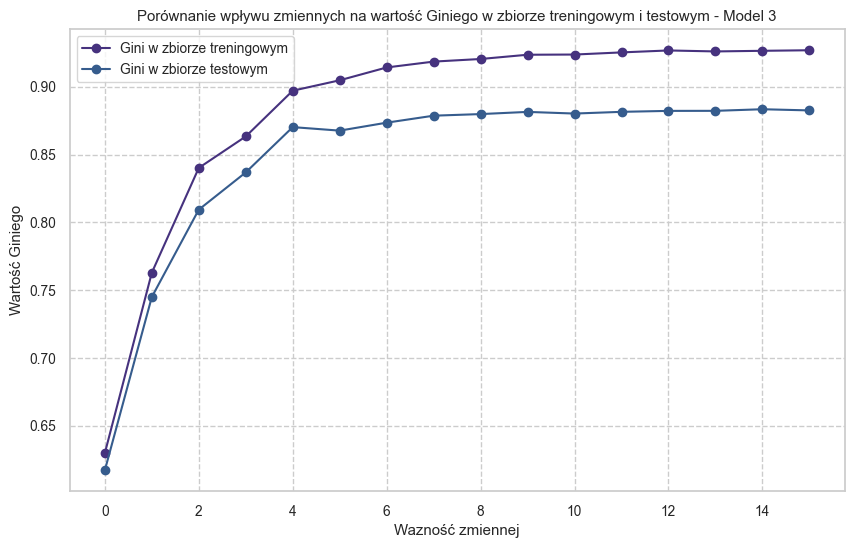

|  | variable | importance | gini_train | gini_test |
| --- | --- | --- | --- | --- |
| 0 | duration | 6.60% | 62.99% | 61.73% |
| 1 | month | 2.58% | 76.30% | 74.50% |
| 2 | pdays | 1.91% | 84.02% | 80.95% |
| 3 | contact | 1.57% | 86.34% | 83.69% |
| 4 | day | 1.38% | 89.72% | 87.03% |
| 5 | balance | 1.08% | 90.49% | 86.77% |
| 6 | age | 0.95% | 91.43% | 87.36% |
| 7 | poutcome | 0.81% | 91.86% | 87.87% |
| 8 | housing | 0.54% | 92.06% | 87.99% |
| 9 | campaign | 0.45% | 92.37% | 88.15% |
| 10 | job | 0.44% | 92.38% | 88.03% |
| 11 | education | 0.31% | 92.54% | 88.16% |
| 12 | marital | 0.26% | 92.69% | 88.23% |
| 13 | loan | 0.21% | 92.61% | 88.23% |
| 14 | previous | 0.16% | 92.66% | 88.35% |
| 15 | default | 0.01% | 92.70% | 88.26% |

```python
gini_var_results_M3_df = draw_gini_vs_variable(model3_labeled,
                                            X_train, y_train, X_test, y_test,
                                            params=loaded_params_M3,
                                            title_name = "Porównanie wpływu zmiennych na wartość Giniego w zbiorze treningowym i testowym - Model 3")
gini_var_results_M3_df.style.format('{:.2%}', subset = ['importance', 'gini_train', 'gini_test'])
```

Analizując przebieg krzywej jakości modelu, można zaobserwować, że w okolicach 10. zmiennej (uszeregowanej według rankingu ważności) współczynnik Gini wchodzi w fazę plateau. Dalsza rozbudowa przestrzeni cech o kolejne predyktory nie przynosi już istotnego przyrostu mocy dyskryminacyjnej klasyfikatora.

Zatem do zredukowanej wersji Modelu 3 zakwalifikowano ostatecznie 10 kluczowych zmiennych: duration, month, pdays, contact, day, balance, age, poutcome, housing oraz campaign.

```python
best_cols_M3 = gini_var_results_M3_df.iloc[0:10].variable
```

```python
model_champion_cand_labeled = xgb.XGBClassifier()

grid_search4 = BayesSearchCV(
    estimator=model_champion_cand_labeled,
    search_spaces=params_space,
    scoring='neg_mean_squared_error',
    n_iter=50,
    cv=3,
    verbose=0,
    random_state=42
)
grid_search4.fit(X_train.loc[:, best_cols_M3], y_train)
```

```
BayesSearchCV(cv=3,
              estimator=XGBClassifier(base_score=None, booster=None,
                                      callbacks=None, colsample_bylevel=None,
                                      colsample_bynode=None,
                                      colsample_bytree=None, device=None,
                                      early_stopping_rounds=None,
                                      enable_categorical=False,
                                      eval_metric=None, feature_types=None,
                                      feature_weights=None, gamma=None,
                                      grow_policy=None, importance_type=None,
                                      interaction_constraints=No...
                             'min_child_weight': Integer(low=1, high=200, prior='uniform', transform='normalize'),
                             'n_estimators': Integer(low=50, high=200, prior='uniform', transform='normalize'),
                             'reg_alpha': Real(low=0.0001, high=10, prior='log-uniform', transform='normalize'),
                             'reg_lambda': Real(low=0.0001, high=10, prior='log-uniform', transform='normalize'),
                             'subsample': Real(low=0.6, high=1.0, prior='uniform', transform='normalize')})
```

```python
grid_search4.best_params_
```

```
OrderedDict([('colsample_bytree', 0.9793308501324652),
             ('gamma', 0.04323835937319436),
             ('learning_rate', 0.08221025487440889),
             ('max_depth', 7),
             ('min_child_weight', 27),
             ('n_estimators', 198),
             ('reg_alpha', 8.692270337290857),
             ('reg_lambda', 4.177058466053788),
             ('subsample', 0.9624682400217787)])
```

```python
model_champ_labeled_results =  model_summary(grid_search4.best_estimator_, 'Model 3r',  'Model zredukowany z parametrami wybranymi w optymalizacji Bayesa z zastosowaniem Label Encoding',
                                X_train.loc[:, best_cols_M3], X_test.loc[:, best_cols_M3], X_valid.loc[:, best_cols_M3],
                                y_train, y_test, y_valid)

models_results = pd.concat([models_results, model_champ_labeled_results]).reset_index(drop = True)
models_results.style.format('{:.2%}', subset = ['Gini_Train', 'Gini_Test', 'Gini_Valid'])
```

|  | Model | Model_Description | Number_of_Vars | Gini_Train | Gini_Test | Gini_Valid |
| --- | --- | --- | --- | --- | --- | --- |
| 0 | Model 1 | Model z domyślnymi parametrami i z zastosowaniem Label Encoding | 16 | 97.05% | 87.49% | 86.22% |
| 1 | Model 2 | Model z domyślnymi parametrami z zastosowaniem Dummy Encoding | 42 | 96.68% | 87.64% | 85.63% |
| 2 | Model 3 | Model z parametrami wybranymi w optymalizacji Bayesa z zastosowaniem Label Encoding | 16 | 92.70% | 88.26% | 87.14% |
| 3 | Model 4 | Model z parametrami wybranymi w optymalizacji Bayesa dla Modelu 3 z zastosowaniem Dummy Encoding | 42 | 92.18% | 88.46% | 87.24% |
| 4 | Model 5 | Model z parametrami wybranymi w optymalizacji Bayesa z zastosowaniem Dummy Encoding | 42 | 89.05% | 88.20% | 86.85% |
| 5 | Model 3r | Model zredukowany z parametrami wybranymi w optymalizacji Bayesa z zastosowaniem Label Encoding | 10 | 89.37% | 88.00% | 87.07% |

Analiza współczynnika Gini na zbiorach treningowym, walidacyjnym oraz testowym wykazała, że w odniesieniu do pełnowymiarowej wersji Modelu 3, zdolność dyskryminacyjna na zbiorach niezależnych uległa jedynie minimalnemu obniżeniu. Kluczowym zjawiskiem jest jednak drastyczny spadek wartości Gini na zbiorze treningowym, przez co wyniki na wszystkich trzech podzbiorach są na podobnym poziomie. Zatem redukcja zmiennych skutecznie wyeliminowała problem nadmiernego dopasowania, pozwalając uzyskać model znacznie stabilniejszy.

Zastosujmy ten sam algorytm sekwencyjny, który bada przyrost współczynnika Gini względem liczby zmiennych do Modelu 5 (opartego na przestrzeni zmiennych rzadkich typu dummy) i wyznaczmy zredukowaną przestrzeń zmiennych.

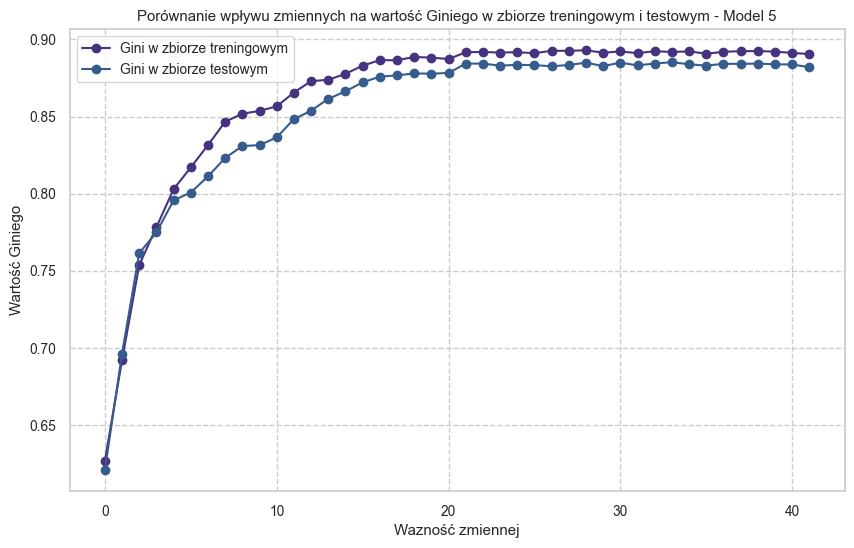

|  | variable | importance | gini_train | gini_test |
| --- | --- | --- | --- | --- |
| 0 | duration | 4.96% | 62.67% | 62.07% |
| 1 | contact_unknown | 1.10% | 69.21% | 69.64% |
| 2 | poutcome_success | 1.03% | 75.37% | 76.15% |
| 3 | day | 0.80% | 77.83% | 77.49% |
| 4 | pdays | 0.43% | 80.29% | 79.57% |
| 5 | balance | 0.32% | 81.70% | 80.08% |
| 6 | housing_yes | 0.29% | 83.15% | 81.12% |
| 7 | age | 0.26% | 84.66% | 82.31% |
| 8 | month_may | 0.22% | 85.18% | 83.09% |
| 9 | marital_married | 0.19% | 85.37% | 83.15% |
| 10 | month_jan | 0.18% | 85.66% | 83.65% |
| 11 | month_jul | 0.17% | 86.55% | 84.83% |
| 12 | campaign | 0.13% | 87.29% | 85.38% |
| 13 | month_mar | 0.13% | 87.38% | 86.14% |
| 14 | month_jun | 0.11% | 87.77% | 86.63% |
| 15 | month_feb | 0.10% | 88.30% | 87.21% |
| 16 | month_aug | 0.09% | 88.65% | 87.59% |
| 17 | month_oct | 0.08% | 88.65% | 87.67% |
| 18 | loan_yes | 0.07% | 88.86% | 87.80% |
| 19 | job_blue-collar | 0.07% | 88.82% | 87.78% |
| 20 | month_sep | 0.05% | 88.72% | 87.83% |
| 21 | month_nov | 0.05% | 89.17% | 88.43% |
| 22 | education_tertiary | 0.05% | 89.19% | 88.43% |
| 23 | job_self-employed | 0.05% | 89.15% | 88.30% |
| 24 | education_secondary | 0.03% | 89.17% | 88.35% |
| 25 | job_management | 0.03% | 89.11% | 88.33% |
| 26 | poutcome_other | 0.03% | 89.26% | 88.26% |
| 27 | previous | 0.02% | 89.26% | 88.34% |
| 28 | month_dec | 0.02% | 89.30% | 88.50% |
| 29 | education_unknown | 0.02% | 89.14% | 88.27% |
| 30 | contact_telephone | 0.02% | 89.22% | 88.50% |
| 31 | job_entrepreneur | 0.02% | 89.11% | 88.32% |
| 32 | job_services | 0.01% | 89.24% | 88.44% |
| 33 | job_housemaid | 0.01% | 89.18% | 88.52% |
| 34 | marital_single | 0.00% | 89.23% | 88.39% |
| 35 | job_retired | 0.00% | 89.07% | 88.30% |
| 36 | job_student | 0.00% | 89.20% | 88.42% |
| 37 | job_unemployed | 0.00% | 89.24% | 88.41% |
| 38 | default_yes | -0.00% | 89.24% | 88.43% |
| 39 | poutcome_unknown | -0.00% | 89.21% | 88.39% |
| 40 | job_unknown | -0.00% | 89.12% | 88.37% |
| 41 | job_technician | -0.01% | 89.05% | 88.20% |

```python
gini_var_results_M5_df = draw_gini_vs_variable(model5_dummy,
                                            X_train_d, y_train, X_test_d, y_test,
                                            params=loaded_params_M5,
                                            title_name = "Porównanie wpływu zmiennych na wartość Giniego w zbiorze treningowym i testowym - Model 5")
gini_var_results_M5_df.style.format('{:.2%}', subset = ['importance', 'gini_train', 'gini_test'])
```

Analizując przebieg krzywej jakości modelu, można zaobserwować, że w okolicach 22. zmiennej (uszeregowanej według rankingu ważności) współczynnik Gini wchodzi w fazę plateau. Dalsza rozbudowa przestrzeni cech o kolejne predyktory nie przynosi już istotnego przyrostu mocy dyskryminacyjnej klasyfikatora.

Zatem do zredukowanej wersji Modelu 5 zakwalifikowano ostatecznie 22 kluczowych zmiennych: duration, contact_unknown, poutcome_success, day, pdays, balance, housing_yes, age, month_may, marital_married, month_jan, month_jul, campaign, month_mar, month_jun, month_feb, month_aug, month_oct, loan_yes, job_blue-collar, month_sep oraz month_nov.

```python
best_cols_M5 = gini_var_results_M5_df.iloc[0:22].variable
```

```python
model_champion_cand_dummy = xgb.XGBClassifier()

grid_seach3 = BayesSearchCV(
    estimator=model_champion_cand_dummy,
    search_spaces=params_space,
    scoring='neg_mean_squared_error',
    n_iter=50,
    cv=3,
    verbose=0,
    random_state=42
)
grid_seach3.fit(X_train_d.loc[:, best_cols_M5], y_train)
```

```
BayesSearchCV(cv=3,
              estimator=XGBClassifier(base_score=None, booster=None,
                                      callbacks=None, colsample_bylevel=None,
                                      colsample_bynode=None,
                                      colsample_bytree=None, device=None,
                                      early_stopping_rounds=None,
                                      enable_categorical=False,
                                      eval_metric=None, feature_types=None,
                                      feature_weights=None, gamma=None,
                                      grow_policy=None, importance_type=None,
                                      interaction_constraints=No...
                             'min_child_weight': Integer(low=1, high=200, prior='uniform', transform='normalize'),
                             'n_estimators': Integer(low=50, high=200, prior='uniform', transform='normalize'),
                             'reg_alpha': Real(low=0.0001, high=10, prior='log-uniform', transform='normalize'),
                             'reg_lambda': Real(low=0.0001, high=10, prior='log-uniform', transform='normalize'),
                             'subsample': Real(low=0.6, high=1.0, prior='uniform', transform='normalize')})
```

```python
model_champ_dummy_results =  model_summary(grid_seach3.best_estimator_, 'Model 5r',
                                     'Model zredukowany z parametrami wybranymi w optymalizacji Bayesa z zastosowaniem Dummy Encoding',
                                X_train_d.loc[:, best_cols_M5], X_test_d.loc[:, best_cols_M5], X_valid_d.loc[:, best_cols_M5],
                                y_train, y_test, y_valid)

models_results = pd.concat([models_results, model_champ_dummy_results]).reset_index(drop = True)
models_results.style.format('{:.2%}', subset = ['Gini_Train', 'Gini_Test', 'Gini_Valid'])
```

|  | Model | Model_Description | Number_of_Vars | Gini_Train | Gini_Test | Gini_Valid |
| --- | --- | --- | --- | --- | --- | --- |
| 0 | Model 1 | Model z domyślnymi parametrami i z zastosowaniem Label Encoding | 16 | 97.05% | 87.49% | 86.22% |
| 1 | Model 2 | Model z domyślnymi parametrami z zastosowaniem Dummy Encoding | 42 | 96.68% | 87.64% | 85.63% |
| 2 | Model 3 | Model z parametrami wybranymi w optymalizacji Bayesa z zastosowaniem Label Encoding | 16 | 92.70% | 88.26% | 87.14% |
| 3 | Model 4 | Model z parametrami wybranymi w optymalizacji Bayesa dla Modelu 3 z zastosowaniem Dummy Encoding | 42 | 92.18% | 88.46% | 87.24% |
| 4 | Model 5 | Model z parametrami wybranymi w optymalizacji Bayesa z zastosowaniem Dummy Encoding | 42 | 89.05% | 88.20% | 86.85% |
| 5 | Model 3r | Model zredukowany z parametrami wybranymi w optymalizacji Bayesa z zastosowaniem Label Encoding | 10 | 89.37% | 88.00% | 87.07% |
| 6 | Model 5r | Model zredukowany z parametrami wybranymi w optymalizacji Bayesa z zastosowaniem Dummy Encoding | 22 | 92.34% | 88.36% | 87.03% |

Analogicznie jak w modelach w wariantach podstawowych, oba zredukowane warianty (Model 3r oraz Model 5r) poddamy ostatecznej weryfikacji za pomocą procedury 10-krotnej walidacji krzyżowej (10-Fold Cross-Validation).

```python
# best_parameters_M3_reduced = grid_search4.best_params_
# best_parameters_M5_reduced = grid_seach3.best_params_

# with open('best_params_M3_labeled_reduced.json', 'w') as f:
#     json.dump(best_parameters_M3_reduced, f, indent=4)

# with open('best_params_M5_dummy_reduced.json', 'w') as f:
#     json.dump(best_parameters_M5_reduced, f, indent=4)

with open('best_params_M3_labeled_reduced.json', 'r') as f:
    loaded_params_M3_r = json.load(f)

with open('best_params_M5_dummy_reduced.json', 'r') as f:
    loaded_params_M5_r = json.load(f)

model3_reduced = xgb.XGBClassifier(**loaded_params_M3_r)
model5_reduced = xgb.XGBClassifier(**loaded_params_M5_r)

model3_reduced.fit(X_train[best_cols_M3], y_train)
model5_reduced.fit(X_train_d[best_cols_M5], y_train)
```

```
XGBClassifier(base_score=None, booster=None, callbacks=None,
              colsample_bylevel=None, colsample_bynode=None,
              colsample_bytree=0.6444637779635654, device=None,
              early_stopping_rounds=None, enable_categorical=False,
              eval_metric=None, feature_types=None, feature_weights=None,
              gamma=0.04944984566872551, grow_policy=None, importance_type=None,
              interaction_constraints=None, learning_rate=0.0408938493973331,
              max_bin=None, max_cat_threshold=None, max_cat_to_onehot=None,
              max_delta_step=None, max_depth=10, max_leaves=None,
              min_child_weight=2, missing=nan, monotone_constraints=None,
              multi_strategy=None, n_estimators=195, n_jobs=None,
              num_parallel_tree=None, ...)
```

```python
# gini_scorer = make_scorer(gini, response_method="predict_proba")

# cv_strategy = StratifiedKFold(n_splits=10, shuffle=True, random_state=20)

model_3_xgb = xgb.XGBClassifier(**loaded_params_M3_r)
model_5_xgb = xgb.XGBClassifier(**loaded_params_M5_r)

# Walidacja dla Modelu 3 (Zredukowany Label Encoding)
scores_m3_r = cross_val_score(
    estimator=model_3_xgb,
    X=X_train[best_cols_M3],
    y=y_train,
    cv=cv_strategy,
    scoring=gini_scorer,
    n_jobs=2
)

# Walidacja dla Modelu 5 (Zredukowany dummy)
scores_m5_r = cross_val_score(
    estimator=model_5_xgb,
    X=X_train_d[best_cols_M5],
    y=y_train,
    cv=cv_strategy,
    scoring=gini_scorer,
    n_jobs=2
)

print("Współczynnik Gini z 10-krotnej walidacji krzyżowej - WARIANTY PODSTAWOWE:")
print(f"Model 1 (Label Encoding Bez Optymalizacji): Średni Gini = {np.mean(scores_m1):.2%} (+/- odchylenie std: {np.std(scores_m1):.2%})")
print(f"Model 2 (Dummy Encoding Bez Optymalizacji): Średni Gini = {np.mean(scores_m2):.2%} (+/- odchylenie std: {np.std(scores_m2):.2%})")
print(f"Model 3 (Label Encoding Z Optymalizacją): Średni Gini = {np.mean(scores_m3):.2%} (+/- odchylenie std: {np.std(scores_m3):.2%})")
print(f"Model 4 (Dummy Encoding Z Optymalizacją Z Modelu 3): Średni Gini = {np.mean(scores_m4):.2%} (+/- odchylenie std: {np.std(scores_m4):.2%})")
print(f"Model 5 (Dummy Encoding Z Optymalizacją ): Średni Gini = {np.mean(scores_m5):.2%} (+/- odchylenie std: {np.std(scores_m5):.2%})")

print("  ")
print("Współczynnik Gini z 10-krotnej walidacji krzyżowej - WARIANTY ZREDUKOWANE:")
print(f"Model 6 (Model 3r, Label Encoding Zredukowany): Średni Gini = {np.mean(scores_m3_r):.2%} (+/- odchylenie std: {np.std(scores_m3_r):.2%})")
print(f"Model 7 (Model 5r, Dummy Encoding Zredukowany): Średni Gini = {np.mean(scores_m5_r):.2%} (+/- odchylenie std: {np.std(scores_m5_r):.2%})")
```

```
Współczynnik Gini z 10-krotnej walidacji krzyżowej - WARIANTY PODSTAWOWE:
Model 1 (Label Encoding Bez Optymalizacji): Średni Gini = 84.46% (+/- odchylenie std: 0.90%)
Model 2 (Dummy Encoding Bez Optymalizacji): Średni Gini = 84.48% (+/- odchylenie std: 0.79%)
Model 3 (Label Encoding Z Optymalizacją): Średni Gini = 85.83% (+/- odchylenie std: 0.94%)
Model 4 (Dummy Encoding Z Optymalizacją Z Modelu 3): Średni Gini = 85.93% (+/- odchylenie std: 0.75%)
Model 5 (Dummy Encoding Z Optymalizacją ): Średni Gini = 85.75% (+/- odchylenie std: 0.81%)

Współczynnik Gini z 10-krotnej walidacji krzyżowej - WARIANTY ZREDUKOWANE:
Model 6 (Model 3r, Label Encoding Zredukowany): Średni Gini = 85.81% (+/- odchylenie std: 1.14%)
Model 7 (Model 5r, Dummy Encoding Zredukowany): Średni Gini = 86.20% (+/- odchylenie std: 0.80%)
```

Z wyników wnioskujemy, ze wariant zredukowany Modelu 5 podniósł średnią wartość współczynnika Gini o blisko 0,45 p.p. w stosunku do jego pełnowymiarowego odpowiednika.

Choć ocena na pojedynczym podziale sugerowała zbyt wysokie dopasowanie modelu opartego na zmiennych typu dummy (Gini na treningu na poziomie 92,34%), to dopiero 10-Fold CV wyznaczyło realną, uśrednioną i wolną od błędu losowości moc dyskryminacyjną obu struktur. Zaobserwowany wcześniej skok jakości na treningu okazał się specyfiką jednego wycinka danych, którą walidacja krzyżowa skutecznie zobiektywizowała.

Wyższa efektywność przestrzeni zmiennych fikcyjnych potwierdza, że po przeprowadzonej redukcji wymiarowości i usunięciu zaszumionych kolumn, binarne podziały wewnątrz drzew XGBoost okazały się dla algorytmu znacznie czytelniejsze i bardziej odporne na wahania niż sztuczne progi narzucone przez kodowanie liczbowe (Label Encoding). W związku z tym Model 5r zostaje wybrany modelem Championem i to on zostanie poddany końcowej analizie.

# 2. Analiza modelu Champion

Z poprzedniej sekcji jako model Champion został wybrany Model 5r, czyli model zbudowany na zmiennych typu Dummy z zredukowaną liczbą zmiennych. Dokonajmy analizy wybranego modelu. Do tego celu zbadamy wazność cech w modelu (za pomocą metryk GAIN i permutation importance), spojrzymy na krzywą ROC i zbadamy wartości SHAP.

W związku z tym przeanalizujmy go w trzech obszarach:

- Analiza ważności cech na bazie metryki zysku (Gain) i metodą ważności permutacyjnej (Permutation Importance).
- Ocena zdolności predykcyjnej (Krzywa ROC): Analiza przebiegu krzywych ROC dla zbiorów treningowego, walidacyjnego i testowego w celu ostatecznej weryfikacji stabilności klasyfikatora.
- Analiza wartości SHAP: Zbadanie kierunkowego wpływu poszczególnych cech na prawdopodobieństwo sukcesu kampanii. Pozwoli to zrozumieć nie tylko które zmienne są istotne, ale w jaki sposób ich konkretne wartości stymulują bądź hamują decyzję klienta o założeniu lokaty.

W pierwszej kolejności przeanalizujemy ważności wybranych zmiennych.

## 2.1 Ważność zmiennych

```python
model_champ = model5_reduced
```

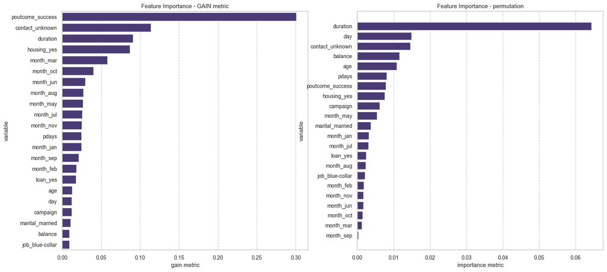

```python
get_feats_plots(model_champ, X_train_d.loc[:, best_cols_M5], y_train)
```

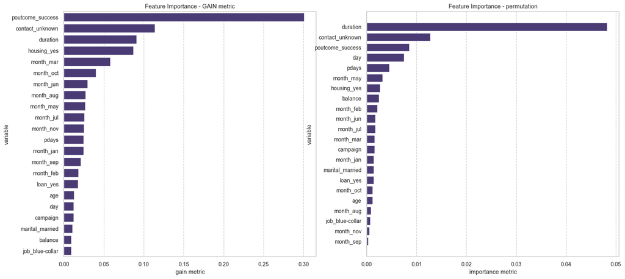

```python
get_feats_plots(model_champ, X_test_d.loc[:, best_cols_M5], y_test)
```

Zestawienie struktur ważności cech potwierdza, że głównym filarem predykcyjnym modelu jest czas trwania relacji z klientem (duration) oraz jego historyczna lojalność (poutcome_success). Zaobserwowane przesunięcia w pozycjach zmiennych day oraz balance pomiędzy próbą uczącą a testową w pełni legitymizują wcześniejsze zastosowanie 10-krotnej walidacji krzyżowej. To właśnie te zmienne generowały lokalny szum, który walidacja krzyżowa poprawnie uśredniła, wskazując na Model 5r jako strukturę stabilną, opartą na fundamentalnych zależnościch biznesowych, a nie na losowych fluktuacjach.

Dodatkowo, analiza porównawcza wykazuje wysoką spójność interpretacyjną, a żaden z badanych predyktorów nie uzyskał ujemnej wartości w teście ważności permutacyjnej na zbiorze testowym. Jest to dowód na to, że żadna z cech nie pogarsza mocy dyskyminacyjnej modelu. Wynik ten ostatecznie potwierdza poprawność i wysoką efektywność przeprowadzonej wcześniej procedury redukcji wymiarowości – w ostatecznej przestrzeni modelu Model 5r pozostawiono wyłącznie zmienne wnoszące realną i stabilną wartość dodaną do końcowego scoringu.

Poniżej przedstawiono krzywą ROC dla zbioru uczącego, testowego i walidacyjnego.

## 2.2 Analiza krzywych ROC

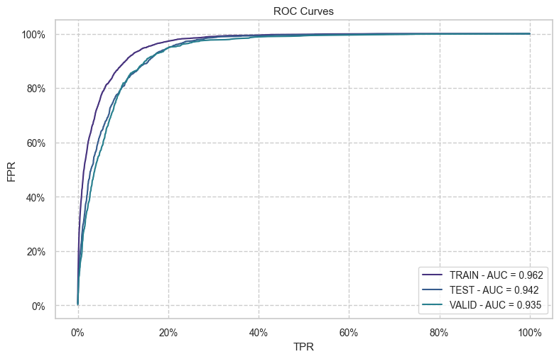

```python
plt.figure(figsize=(8, 5))

roc_curve_plot(y_train, model_champ.predict_proba(X_train_d.loc[:, best_cols_M5])[:, 1], dataset_type = 'TRAIN')
roc_curve_plot(y_test, model_champ.predict_proba(X_test_d.loc[:, best_cols_M5])[:, 1], dataset_type = 'TEST')
roc_curve_plot(y_valid, model_champ.predict_proba(X_valid_d.loc[:, best_cols_M5])[:, 1], dataset_type = 'VALID')
plt.tight_layout()
plt.title(f"ROC Curves")
plt.show()
```

Gładki przebieg krzywej na odłożonej próbie testowej oraz jej minimalne odchylenie od krzywej wzorcowej (treningowej) stanowi wizualny dowód stabilności modelu wiodącego. Wąska luka obserwowana w każdym punkcie wykresu potwierdza, że proces redukcji wymiarowości zniwelował nadmierne dopasowanie.

Ostatnim etapem analizy model jest badanie wartości SHAP.

## 2.3 Analiza wartości SHAP

W celu dokonania interpretacji decyzji modelowych, analizę wartości SHAP przeprowadzono na zbiorze testowym. To podejście pozwala na ocenę kierunkowego wpływu zmiennych na populacji klientów niewykorzystywanej w procesie uczenia algorytmu.

```python
explainer = shap.TreeExplainer(model_champ, X_test_d.loc[:, best_cols_M5].astype(float))
shap_values = explainer.shap_values(X_test_d.loc[:, best_cols_M5])
```

```
100%|===================| 9023/9042 [05:22<00:00]
```

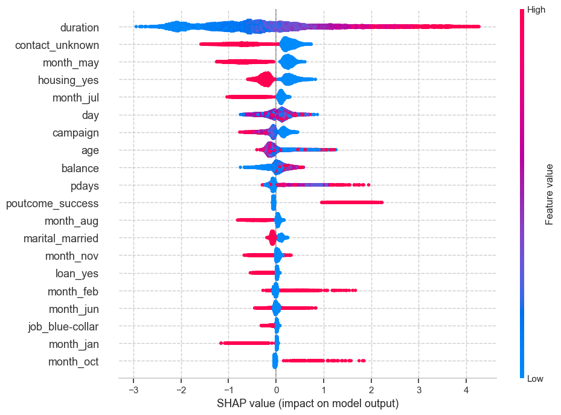

```python
shap.summary_plot(shap_values, X_test_d.loc[:, best_cols_M5], plot_size=(10, 7))
```

Analiza wartości SHAP dla modelu Championa jednoznacznie wskazuje, że filarem skuteczności predykcyjnej są czynniki operacyjne oraz historia dotychczasowej współpracy.

# Podsumowanie

Analizy przeprowadzone w raporcie potwierdziły, że dane charakteryzuje się bardzo wysokim potencjałem predykcyjnym oraz stabilnością struktury w podziale na próby treningową, walidacyjną i testową.

Silne zależności zidentyfikowane na etapie eksploracji jakościowej znalazły odzwierciedlenie w końcowym procesie modelowania klasyfikatorem XGBoost. Zastosowanie optymalizacji Bayesowskiej poprawiło jakość modeli bazowych (wzrost średniego Gini o ok. 1,4 p.p.), natomiast iteracyjna redukcja wymiarowości na przestrzeni zmiennych fikcyjnych wyłoniła ostatecznego Championa — Model 5r (Zredukowany Dummy Encoding).

Model ten osiągnął najwyższy w całym badaniu, uśredniony w 10-krotnej walidacji krzyżowej współczynnik Gini na poziomie 86,20% przy minimalnej wariancji między foldami ($\text{std} = 0,80\%$). Analiza krzywych ROC na zbiorach niezależnych wykazała niskie różnice pomiędzy krzywą na zbiorze uczącym, co dowodzi, że algorytm trwale odrzucił lokalny szum na rzecz globalnych prawidłowości rynkowych.

Biorąc pod uwagę najwyższą moc dyskryminacyjną, odporność na wahania próby oraz pełną transparentność decyzyjną, Model 5r należy uznać za wariant optymalny i cechujący się najwyższą efektywnością wśród wszystkich analizowanych klasyfikatorów.